# Introducción a Stata 13

Ana E.

Curso TeTra 25 sept 2017

## STATA y su pantalla

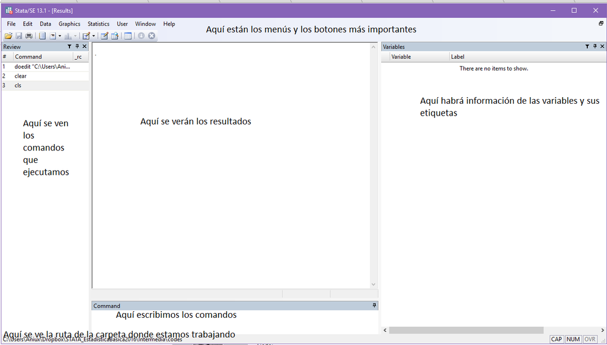

Pero además utilizaremos otras pantallas. Una muy útil es la de el **do-file**. Aquí copiamos los comandos para no olvidar lo que hemos hecho en nuestra base de datos y poderlo replicar. Documentar nuestro código es importante para la replicabilidad (de nosotros mismos y de los demás)

[figure not shown]

Otra muy útil es la edición de datos, **“Edit”**. Parece una hoja de Excel y podemos editar los datos directamente, capturales, ponerles nombre, etiquetarlos.

[figure not shown]

**¡Tip!** Es muy útil usar en lugar de la edición, la de “Revisión” **“Browse”**. Se ve aparentemente igual. Pero sólo inspecciona y no cambia. Esto es útil, porque si editamos es mucho mejor hacerlo por comando para que quede claro qué hicimos con nuestra base de datos

[figure not shown]

# STATA con comandos

## STATA como una gran calculadora

El comando más simple es comando “display”, este comando nos presenta en la pantalla de resultados las operaciones que le pidamos.

```stata
display  "hola"
di 5+3
di chi2(10, 85)
```

```
.
. display  "hola"
hola

. di 5+3
8

. di chi2(10, 85)
1

.
```

Pedir ayuda (Nota, con un asterisco los comandos no se vuelven de “chocolate”)

```stata
*help display

*help chi2

help operators
```

```
.
. *help display
.
. *help chi2
.
. help operators
request ignored because of batch mode
```

[figure not shown]

Los operadores son importantísimos porque nos ayudan a poner filtros y saber cómo “lee” nuestras indicaciones STATA

## Usando bases de datos

Puedes decargar la base de [aquí](https://www.dropbox.com/sh/6ik3m33ngop98nx/AAA2bNQBlS1JUUYFeHEhdyOUa?dl=0)

Podemos hacerlo una base de datos “manualmente” usando: los botones de “abrir” File -> Open o Los botones CTRL + O

[figure not shown]

O podemos usar el comando “use”, entre comillas debemos poner el nombre de la dirección correspondiente a nuestro archivo

```stata
use "C:\Users\Aniux\Dropbox\Curso_teTra\datos\sdemt217.dta", clear
describe
browse
bro
```

```
. use "C:\Users\Aniux\Dropbox\Curso_teTra\datos\sdemt217.dta", clear

. describe

Contains data from C:\Users\Aniux\Dropbox\Curso_teTra\datos\sdemt217.dta
  obs:       398,017
 vars:           104
 size:   103,882,437
--------------------------------------------------------------------------------------------------------------------------------------------------------------------
              storage   display    value
variable name   type    format     label      variable label
--------------------------------------------------------------------------------------------------------------------------------------------------------------------
r_def           str2    %2s
loc             str4    %4s
mun             str3    %3s
est             str2    %2s
est_d           int     %8.0g
ageb            str5    %5s
t_loc           str1    %1s
cd_a            str2    %2s
ent             str2    %2s
con             str5    %5s
upm             str7    %7s
d_sem           str3    %3s
n_pro_viv       str4    %4s
v_sel           str2    %2s
n_hog           str1    %1s
h_mud           str1    %1s
n_ent           str1    %1s
per             str3    %3s
n_ren           str2    %2s
c_res           str1    %1s
par_c           str3    %3s
sex             str1    %1s
eda             str2    %2s
nac_dia         str2    %2s
nac_mes         str2    %2s
nac_anio        str4    %4s
l_nac_c         str3    %3s
cs_p12          str1    %1s
```

[output cut: 71 more lines]

```
tue_ppal        byte    %8.0g
trans_ppal      byte    %8.0g
mh_fil2         byte    %8.0g
mh_col          byte    %8.0g
sec_ins         byte    %8.0g
--------------------------------------------------------------------------------------------------------------------------------------------------------------------
Sorted by:

. browse
request ignored because of batch mode

. bro
request ignored because of batch mode

.
```

[figure not shown]

A veces es mucho más sencillo establecer un documento de trabajo, sobre todo cuando trabajo desde distintas computadoras

```stata
cd "C:\Users\Aniux\Dropbox\Curso_teTra\datos"
use sdemt217.dta, clear
```

```
.
. cd "C:\Users\Aniux\Dropbox\Curso_teTra\datos"
C:\Users\Aniux\Dropbox\Curso_teTra\datos

. use sdemt217.dta, clear
```

## Comandos útiles de inspección de Bases de datos

```stata
  use "C:\Users\Aniux\Dropbox\Curso_teTra\datos\sdemt217.dta", clear
describe
summarize

*Estos dos comandos si no ponemos variables toman toda la base de datos. Si queremos para

*Tip!, STATA entiende los comandos acortados, y podemos poner "su" en lugar de "summarize"

su sex

*¿Cómo sabemos hasta donde se acorta, ponemos help al comando y lo que esté subryado es qué tanto podemos abreviar


*Podemos usar el asterisco para abreviar un listado de variables que empiezan igual, por ejemplo
su clase*

*Otra herramienta útil es el codebook, nos permite saber qué tipos de variables tenemos

codebook clase*

*En STATA, cada comando tiene "opciones", son parámetros que establecemos despues de la sintaxis normal del comando despues de una ","
*En este caso, queremos escribir la versión compacta del codebook, escribimos después de la coma ", compact"

codebook clase*, compact

*También estas opciones se pueden abreviar

codebook clase*, c
```

```
.   use "C:\Users\Aniux\Dropbox\Curso_teTra\datos\sdemt217.dta", clear

. describe

Contains data from C:\Users\Aniux\Dropbox\Curso_teTra\datos\sdemt217.dta
  obs:       398,017
 vars:           104
 size:   103,882,437
--------------------------------------------------------------------------------------------------------------------------------------------------------------------
              storage   display    value
variable name   type    format     label      variable label
--------------------------------------------------------------------------------------------------------------------------------------------------------------------
r_def           str2    %2s
loc             str4    %4s
mun             str3    %3s
est             str2    %2s
est_d           int     %8.0g
ageb            str5    %5s
t_loc           str1    %1s
cd_a            str2    %2s
ent             str2    %2s
con             str5    %5s
upm             str7    %7s
d_sem           str3    %3s
n_pro_viv       str4    %4s
v_sel           str2    %2s
n_hog           str1    %1s
h_mud           str1    %1s
n_ent           str1    %1s
per             str3    %3s
n_ren           str2    %2s
c_res           str1    %1s
par_c           str3    %3s
sex             str1    %1s
eda             str2    %2s
nac_dia         str2    %2s
nac_mes         str2    %2s
nac_anio        str4    %4s
l_nac_c         str3    %3s
cs_p12          str1    %1s
```

[output cut: 297 more lines]

```
--------------------------------------------------------------------------------------------------------------------------------------------------------------------

.
. *También estas opciones se pueden abreviar
.
. codebook clase*, c

Variable      Obs Unique      Mean  Min  Max  Label
--------------------------------------------------------------------------------------------------------------------------------------------------------------------
clase1     398017      3   1.12201    0    2
clase2     398017      5  1.768201    0    4
clase3     398017      8  .5625915    0    7
--------------------------------------------------------------------------------------------------------------------------------------------------------------------

.
```

## Descriptivos sencillos

Tabulados

```stata
use "C:\Users\Aniux\Dropbox\Curso_teTra\datos\sdemt217.dta", clear

tabulate sex
tab sex
```

```
. use "C:\Users\Aniux\Dropbox\Curso_teTra\datos\sdemt217.dta", clear

.
. tabulate sex

        sex |      Freq.     Percent        Cum.
------------+-----------------------------------
          1 |    189,243       48.39       48.39
          2 |    201,828       51.61      100.00
------------+-----------------------------------
      Total |    391,071      100.00

. tab sex

        sex |      Freq.     Percent        Cum.
------------+-----------------------------------
          1 |    189,243       48.39       48.39
          2 |    201,828       51.61      100.00
------------+-----------------------------------
      Total |    391,071      100.00

.
```

## Gráficos

```
. use "C:\Users\Aniux\Dropbox\Curso_teTra\datos\sdemt217.dta", clear

.
. histogram anios_esc
(bin=55, start=0, width=1.8)

.
```

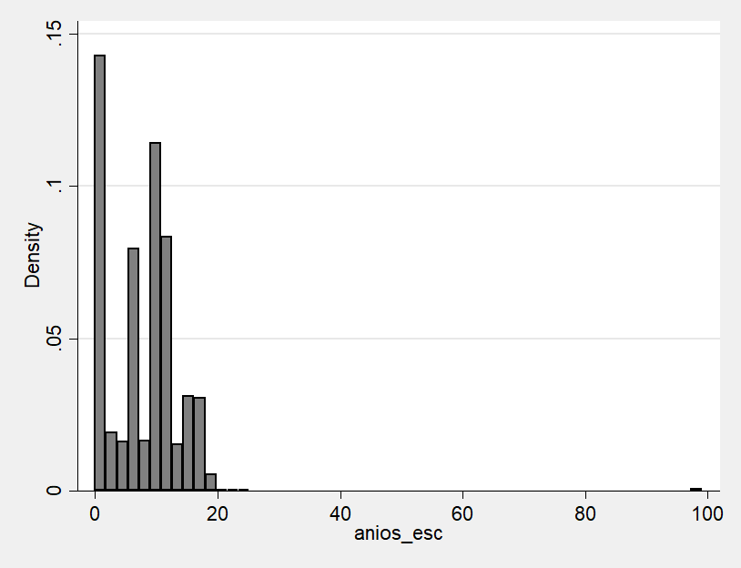

```stata
use "C:\Users\Aniux\Dropbox\Curso_teTra\datos\sdemt217.dta", clear

histogram anios_esc
```

## Generando variables

```
. use "C:\Users\Aniux\Dropbox\Curso_teTra\datos\sdemt217.dta", clear

.
. generate nueva_var=1

.
. generate nueva_var2=.
(398017 missing values generated)

.
. replace nueva_var=nueva_var2
(398017 real changes made, 398017 to missing)

. replace nueva_var=1 if sex==2
type mismatch
r(109);

end of do-file
r(109);
```

[figure not shown]

```stata
use "C:\Users\Aniux\Dropbox\Curso_teTra\datos\sdemt217.dta", clear

generate nueva_var=1

generate nueva_var2=.

replace nueva_var=nueva_var2
replace nueva_var=1 if sex==2

gen log_ing_hrs=log(ing_x_hrs)
histogram log_ing_hrs, freq normal
```

## Transformación de variables

```stata
use "C:\Users\Aniux\Dropbox\Curso_teTra\datos\sdemt217.dta", clear

*De cadena a numérica

destring eda, gen(edad2)
destring eda, replace

*De númerica a cadena
encode est, gen(edo)
```

```
. use "C:\Users\Aniux\Dropbox\Curso_teTra\datos\sdemt217.dta", clear

.
. *De cadena a numérica
.
. destring eda, gen(edad2)
eda has all characters numeric; edad2 generated as byte
(6946 missing values generated)

. destring eda, replace
eda has all characters numeric; replaced as byte
(6946 missing values generated)

.
. *De númerica a cadena
. encode est, gen(edo)
```

## Etiquetado de variables

```stata
use "C:\Users\Aniux\Dropbox\Curso_teTra\datos\sdemt217.dta", clear

destring sex, replace
label var sex "Sexo del entrevistado"

label define sexlabel 1 "Hombre" 2 "Mujer", modify

label values sex sexlabel

tab sex
tab sex, nolabel

tab eda sex
```

```
. use "C:\Users\Aniux\Dropbox\Curso_teTra\datos\sdemt217.dta", clear

.
. destring sex, replace
sex has all characters numeric; replaced as byte
(6946 missing values generated)

. label var sex "Sexo del entrevistado"

.
. label define sexlabel 1 "Hombre" 2 "Mujer", modify

.
. label values sex sexlabel

.
. tab sex

   Sexo del |
entrevistad |
          o |      Freq.     Percent        Cum.
------------+-----------------------------------
     Hombre |    189,243       48.39       48.39
      Mujer |    201,828       51.61      100.00
------------+-----------------------------------
      Total |    391,071      100.00

. tab sex, nolabel

   Sexo del |
entrevistad |
          o |      Freq.     Percent        Cum.
------------+-----------------------------------
          1 |    189,243       48.39       48.39
          2 |    201,828       51.61      100.00
------------+-----------------------------------
      Total |    391,071      100.00

.
. tab eda sex
```

[output cut: 92 more lines]

[output not shown]